# TLimmno2: MHC II immunogenicity prediction network based on transfer learning

```python
import pandas as pd
import matplotlib.pyplot as plt
import matplotlib as mpl
mpl.rcParams['pdf.fonttype'] = 42
mpl.rcParams['ps.fonttype'] = 42
plt.rcParams.update({'font.family':'Arial'})
import seaborn as sns
import numpy as np
from sklearn.metrics import confusion_matrix,accuracy_score
from sklearn.metrics import roc_curve,auc,confusion_matrix,precision_score,recall_score,precision_recall_curve
import matplotlib as mpl
path = "~/Project/Documenet/TLIMM2pred/data/"
import random
```

This part focuses on TLimmuno2 model construction. it contains the following sections:

## Data preprocessing

Immunogenicity molecular assays were downloaded from the Immune Epitope Database (IEDB) on May 15, 2022. The following keywords were used: Linear peptide; T cell; Include positive and negative; MHC II; Human and any disease. We next used strict criteria for data cleaning. First, data instances without explicit 4-digit MHC alleles were discarded. Second, the length of the peptides is limited in the range of 13-21 mer. Third, the data with low confidence (no information in number of subjects tested/responded) were removed. Finally, we chose five experiment types, “51 chromium”, “ELISA”, “ELISPOT”, “ICS” and “multimer/tetramer” to train model as the reason of we think these are more reliable. The rest of experiment types is used for model benchmark. In the final, we got 3930 positive instances and 2478 negative instances for training, and 105 positive instances and 4 negative instances for benchmark.

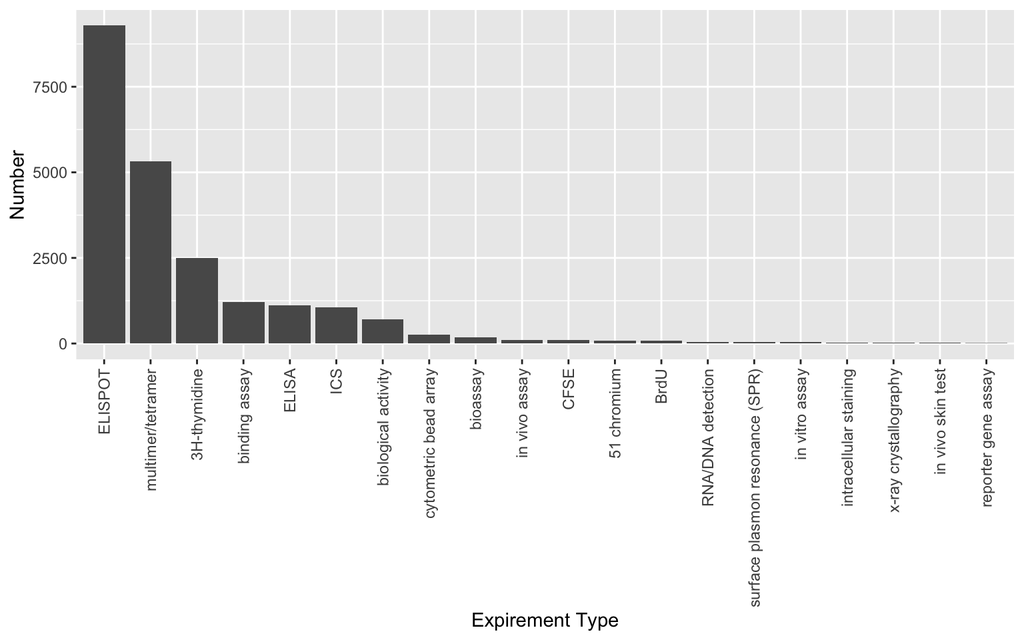

```r
#R
IEDB_immuno_MHCII <- read_csv("../data/IEDB_MHCII.csv")
pseduo_seq <- read_table("../data/pseudosequence.2016.all.X.dat",col_names = c("allele","sequence"))
colnames(IEDB_immuno_MHCII) <- IEDB_immuno_MHCII[1,]
IEDB_immuno_MHCII <- IEDB_immuno_MHCII[-1,]
IEDB_immuno_MHCII_filter <- IEDB_immuno_MHCII[,c(12,85,88,102,91,92,93)]  #4:pubmed ID
IEDB_immuno_MHCII_filter$`Qualitative Measure` <- str_replace(IEDB_immuno_MHCII_filter$`Qualitative Measure`,"Positive-High","Positive")
IEDB_immuno_MHCII_filter$`Qualitative Measure` <- str_replace(IEDB_immuno_MHCII_filter$`Qualitative Measure`,"Positive-Intermediate","Positive")
IEDB_immuno_MHCII_filter$`Qualitative Measure` <- str_replace(IEDB_immuno_MHCII_filter$`Qualitative Measure`,"Positive-Low","Positive")
IEDB_immuno_MHCII_filter <- IEDB_immuno_MHCII_filter[!(duplicated(IEDB_immuno_MHCII_filter)),]
IEDB_immuno_MHCII_filter$length <- sapply(IEDB_immuno_MHCII_filter$Description, nchar)
#add method ratio
IEDB_immuno_assay <- IEDB_immuno_MHCII_filter %>% filter(nchar(`Allele Name`)>=14) %>% filter(length>=13&length<=21) %>% group_by(`Method/Technique`) %>% summarise(num = n())
ggplot(data = IEDB_immuno_assay)+
  geom_col(aes(x = reorder(`Method/Technique`,-num),y=num))+xlab("Expirement Type")+ylab("Number") + theme(axis.text.x = element_text(angle=90, hjust=1, vjust=.5))
```

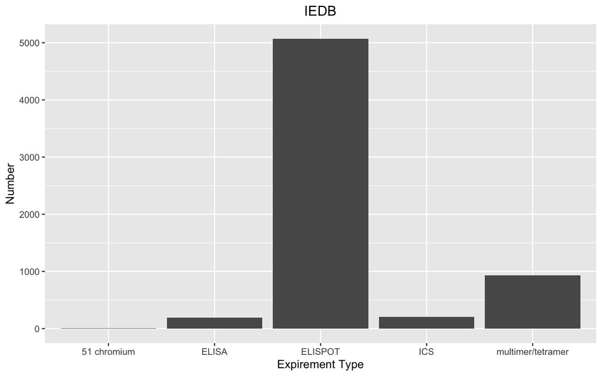

```r
ggsave("../figure/IEDB_assay_type.pdf")

IEDB_immuno_MHCII_filter1 <- IEDB_immuno_MHCII_filter %>% filter(nchar(`Allele Name`)>=14) %>% filter(length>=13&length<=21) %>%
  filter(`Method/Technique`=="51 chromium"|`Method/Technique`=="ELISA"|`Method/Technique`=="ELISPOT"|`Method/Technique`=="ICS"|`Method/Technique`=="multimer/tetramer") %>% filter(str_detect(`Allele Name`,"HLA"))
fun <- function(x){
  if (str_detect(x,"\\/")){
    x = str_remove_all(x,"\\*")
    x = str_remove_all(x,"\\:")
    x = str_replace(x,"\\/","-")
  }
  else{
    x = str_replace(x,"HLA-","")
    x = str_replace(x,"\\*","_")
    x = str_replace(x,"\\:","")
  }
  return(x)
}
IEDB_immuno_MHCII_filter1$`Allele Name1` <- sapply(IEDB_immuno_MHCII_filter1$`Allele Name`,fun)
IEDB_immuno_MHCII_filter1 <- left_join(IEDB_immuno_MHCII_filter1,pseduo_seq, by = c("Allele Name1" = "allele"))
IEDB_immuno_MHCII_filter_final <-  na.omit(IEDB_immuno_MHCII_filter1)  #with response
IEDB_immuno_MHCII_filter_final <- IEDB_immuno_MHCII_filter_final[!(duplicated(IEDB_immuno_MHCII_filter_final[,c(1,4)])),]

MHC_immuno_allele <- unique((IEDB_immuno_MHCII_filter_final$`Allele Name1`))
write_lines(MHC_immuno_allele,"../data/IEDB_MHCII_immuno_allele.csv")
write_csv(IEDB_immuno_MHCII_filter_final,"../data/IEDB_MHCII_immuno.csv")
# plt fig
ggplot(data = IEDB_immuno_MHCII_filter_final)+
  geom_histogram(aes(x = `Method/Technique`),stat = "count")+xlab("Expirement Type")+ylab("Number") + labs(title = "IEDB")+ theme(plot.title = element_text(hjust = 0.5))
```

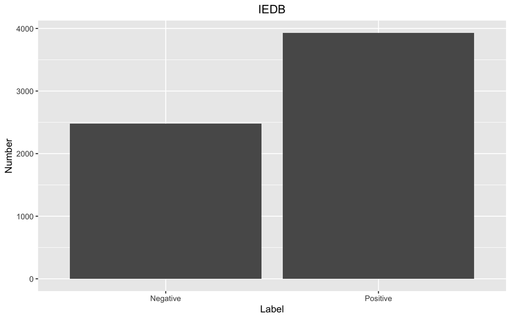

```r
ggplot(data = IEDB_immuno_MHCII_filter_final)+
  geom_histogram(aes(x = `Qualitative Measure`),stat = "count")+xlab("Label")+ylab("Number") + labs(title = "IEDB")+ theme(plot.title = element_text(hjust = 0.5))
```

Data for benchmark:

NEW!! These part is deleated in the paper.

```r
#R
IEDB_immuno_MHCII_filter2 <- IEDB_immuno_MHCII_filter %>% filter(nchar(`Allele Name`)>=14) %>% filter(length>=13&length<=21) %>%
  filter(!(`Method/Technique`=="51 chromium"|`Method/Technique`=="ELISA"|`Method/Technique`=="ELISPOT"|`Method/Technique`=="ICS"|`Method/Technique`=="multimer/tetramer")) %>%
  filter(str_detect(`Allele Name`,"HLA"))

IEDB_immuno_MHCII_filter2$`Allele Name1` <- sapply(IEDB_immuno_MHCII_filter2$`Allele Name`,fun)
IEDB_immuno_MHCII_filter2 <- left_join(IEDB_immuno_MHCII_filter2,pseduo_seq, by = c("Allele Name1" = "allele"))
IEDB_immuno_MHCII_benchmark <-  na.omit(IEDB_immuno_MHCII_filter2) # only response
IEDB_immuno_MHCII_benchmark <- IEDB_immuno_MHCII_benchmark[!(duplicated(IEDB_immuno_MHCII_benchmark[,c(1,4)])),]
bool1 <- IEDB_immuno_MHCII_benchmark$Description %in% IEDB_immuno_MHCII_filter_final$Description
bool2 <- IEDB_immuno_MHCII_benchmark$`Allele Name` %in% IEDB_immuno_MHCII_filter_final$`Allele Name`
IEDB_immuno_MHCII_benchmark_final <- IEDB_immuno_MHCII_benchmark[!(bool1&bool2),]
#write_csv(IEDB_immuno_MHCII_benchmark_final,"../data/IEDB_benchmark.csv")
```

We also analyzed the distribution of HLA types in the immunogenicity data and found that it has a similar distribution to the Binding affinity data, and the peptides with a length of 15mer accounted for the largest proportion.

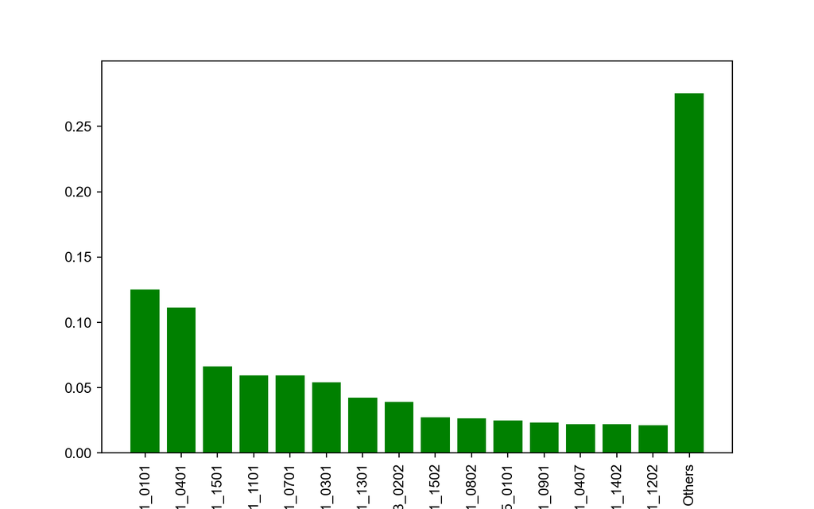

```python
IMM_data = pd.read_csv("/Users/wangguangshuai/Data/MHCII/Data/IMM_model_train/IEDB_MHCII_immuno.csv")
sns.barplot(IMM_data["Qualitative Measure"].value_counts().index,IMM_data["Qualitative Measure"].value_counts().values,palette =["green","red"])
plt.xlabel("Label")
plt.ylabel("Number")
plt.savefig("../figure/IMM_label.pdf",dpi = 300,transparent=True)
allele_pos = IMM_data[IMM_data["Qualitative Measure"] == "Positive"]
x = pd.DataFrame(allele_pos["Allele Name1"].value_counts())
x["frac"] = x["Allele Name1"].map(lambda y: y/sum(x["Allele Name1"].values))
a = list(x.index[0:15])
b = list(x["frac"].values[0:15])
a.append("Others")
b.append(sum(x["frac"].values[15:]))
fig,ax = plt.subplots()
plt.bar(a,b,color = "green")
#> <BarContainer object of 16 artists>
plt.ylim([0,0.3])
#> (0.0, 0.3)
plt.yticks([0.00,0.05,0.10,0.15,0.20,0.25])
#> ([<matplotlib.axis.YTick object at 0x29b099cd0>, <matplotlib.axis.YTick object at 0x299f94580>, <matplotlib.axis.YTick object at 0x29b0eedf0>, <matplotlib.axis.YTick object at 0x299f2a730>, <matplotlib.axis.YTick object at 0x299f84a30>, <matplotlib.axis.YTick object at 0x29b0a7fa0>], [Text(0, 0, ''), Text(0, 0, ''), Text(0, 0, ''), Text(0, 0, ''), Text(0, 0, ''), Text(0, 0, '')])
plt.xticks(rotation = 90)
#> ([0, 1, 2, 3, 4, 5, 6, 7, 8, 9, 10, 11, 12, 13, 14, 15], [Text(0, 0, ''), Text(0, 0, ''), Text(0, 0, ''), Text(0, 0, ''), Text(0, 0, ''), Text(0, 0, ''), Text(0, 0, ''), Text(0, 0, ''), Text(0, 0, ''), Text(0, 0, ''), Text(0, 0, ''), Text(0, 0, ''), Text(0, 0, ''), Text(0, 0, ''), Text(0, 0, ''), Text(0, 0, '')])
plt.savefig("../figure/allele_pos.pdf",dpi = 300,bbox_inches='tight',transparent=True)
plt.show()
```

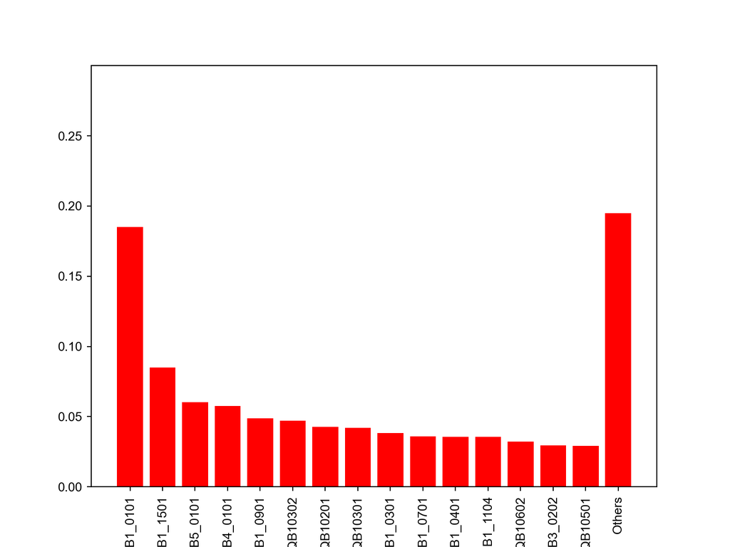

```python
allele_neg = IMM_data[IMM_data["Qualitative Measure"] == "Negative"]
x = pd.DataFrame(allele_neg["Allele Name1"].value_counts())
x["frac"] = x["Allele Name1"].map(lambda y: y/sum(x["Allele Name1"].values))
a = list(x.index[0:15])
b = list(x["frac"].values[0:15])
a.append("Others")
b.append(sum(x["frac"].values[15:]))
fig,ax = plt.subplots(figsize = (8,6))
ax = plt.bar(a,b,color = "red")
plt.ylim([0,0.3])
#> (0.0, 0.3)
plt.yticks([0.00,0.05,0.10,0.15,0.20,0.25])
#> ([<matplotlib.axis.YTick object at 0x29b0c3730>, <matplotlib.axis.YTick object at 0x299f841f0>, <matplotlib.axis.YTick object at 0x299f2abe0>, <matplotlib.axis.YTick object at 0x29b0a0700>, <matplotlib.axis.YTick object at 0x29b0a08e0>, <matplotlib.axis.YTick object at 0x29b0699a0>], [Text(0, 0, ''), Text(0, 0, ''), Text(0, 0, ''), Text(0, 0, ''), Text(0, 0, ''), Text(0, 0, '')])
plt.xticks(rotation = 90)
#> ([0, 1, 2, 3, 4, 5, 6, 7, 8, 9, 10, 11, 12, 13, 14, 15], [Text(0, 0, ''), Text(0, 0, ''), Text(0, 0, ''), Text(0, 0, ''), Text(0, 0, ''), Text(0, 0, ''), Text(0, 0, ''), Text(0, 0, ''), Text(0, 0, ''), Text(0, 0, ''), Text(0, 0, ''), Text(0, 0, ''), Text(0, 0, ''), Text(0, 0, ''), Text(0, 0, ''), Text(0, 0, '')])
plt.savefig("../figure/allele_neg.pdf",dpi = 300,transparent=True)
plt.show()
```

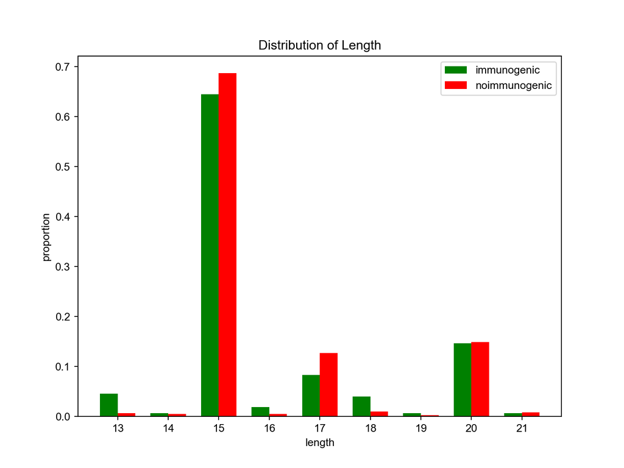

```python
pos_len_value = list(allele_pos["length"].value_counts().values)
pos_len_index = allele_pos["length"].value_counts().index
norm_pos_len_value = allele_pos["length"].value_counts().values/sum(allele_pos["length"].value_counts())
neg_len_value = list(allele_neg["length"].value_counts().values)
neg_len_index = allele_neg["length"].value_counts().index
norm_neg_len_value = allele_neg["length"].value_counts().values/sum(allele_neg["length"].value_counts())
fig,ax = plt.subplots(figsize = (8,6))
width = 0.35
x = pos_len_index
ax.bar(pos_len_index - width/2, norm_pos_len_value,width,label='immunogenic',color = "green")
#> <BarContainer object of 9 artists>
ax.bar(neg_len_index + width/2, norm_neg_len_value, width, label='noimmunogenic',color = "red")
#> <BarContainer object of 9 artists>
ax.set_ylabel('proportion')
ax.set_xlabel('length')
ax.set_title('Distribution of Length')
ax.set_xticks(x)
ax.legend()
plt.savefig("../figure/length.pdf",dpi = 300,transparent=True)
plt.show()
```

### Get random peptide as decoay

In our data, we found that the percentage of data with immunogenic peptides is more than the percentage of data without immunogenicity. The reason for this problem is that the data without response information (number of subjects tested/responded) in the IEDB dataset are also considered as negative peptides and we removed them during data cleaning. To avoid this anomaly, we used all human peptide sequence download from the universal protein knowledgebase (UniProt) database (2022.3) to get random artificial negative peptides. We generated 2 times and 5 times random peptides for each length of each MHC allele as negative instances to construct IEDB-training dataset and IEDB-benchmark dataset.

```python
#python
f=open("../data/uniport_human.fasta")
ls=[]
for line in f:
        if not line.startswith('>'):
                ls.append(line.replace('\n',''))
f.close()
uniport = pd.DataFrame(ls)
uniport["length"] = uniport[0].map(len)
bool = uniport["length"]>30
uniport = uniport[bool]
bool = uniport[0].apply(lambda x: set(list(x)).issubset(set(list("ARNDCQEGHILKMFPSTWYVX"))))
uniport = uniport[bool]
uniport_random = uniport[0].values
def random_select(x,length,num,allele):
    df = []
    all = []
    for i in range(num):
        protein_num = random.randint(0,len(x)-1)
        protein = x[protein_num]
        peptide_num = random.randint(0,len(protein)-length)
        peptide = protein[peptide_num:peptide_num+length]
        df.append(peptide)
        all.append(allele)
    return df,all
IMM_data = pd.read_csv("../data/IEDB_MHCII_immuno.csv")
negative = []
allele = []
time = 2 # negative times, 2 for IEDB-training and 5 for IEDB-benchmark
for i in range(time):
    for i in IMM_data["Allele Name1"].unique():
        smal_IMM = IMM_data[IMM_data["Allele Name1"] == i]["length"].value_counts()
        for l in range(len(smal_IMM)):
            length = int(smal_IMM.index[l])
            num = int(smal_IMM.values[l])
            pep,all = random_select(uniport_random,length,num,i)
            negative.extend(pep)
            allele.extend(all)

IMM_data = IMM_data[["Description","Qualitative Measure","Allele Name1"]]
random_data = pd.DataFrame({"Description":negative,"Allele Name1":allele})
random_data["Qualitative Measure"] = "Negative"
final_data = pd.concat([IMM_data,random_data],axis=0)
final_data["label"] = final_data["Qualitative Measure"].map(lambda x : 1 if x == "Positive" else 0)
final_data = final_data.drop_duplicates()
pseudo_data = pd.read_table("../data/pseudosequence.2016.all.X.dat",header=None,names=["Allele Name1","sequence"])
pseudo_data = pseudo_data.drop_duplicates()
Data = pd.merge(final_data,pseudo_data).drop_duplicates()
#Data.to_csv("../data/IMM_data_random{}.csv".format(time))
```

## Model train

We employed transfer learning to add binding affinity information by extract penultimate layer of BA model. We also used LSTM layers to get antigen and MHC information, because we found our model got a great significant improvement by using this method. We concatenated the three numerical vectors into a single layer, added a dense layer with 400 neurons activated by RELU, a dense layer with 200 neurons activated by RELU and the last layer with a single neuron with sigmoid activation.We named the final model of MHC II immunogenicity prediction network based on transfer learning as “TLimmuno2”.

```python
#PBS
#python
import pandas as pd
import os
import tensorflow as tf
from tensorflow import keras
from tensorflow.keras import layers
from tensorflow.keras.layers import *
from sklearn.model_selection import train_test_split,KFold
import numpy as np
from collections import Counter
from sklearn.metrics import auc,precision_recall_curve,roc_curve,confusion_matrix,average_precision_score
from collections import Counter
import matplotlib.pyplot as plt
import sys
sys.path.append("/public/slst/home/wanggsh/Project/MHCII/utils")
from Blosum62 import blosum62
#Data process
immuno_data = pd.read_csv("/public/slst/home/wanggsh/Data/MHCII_immuno/IMM_data_random2.csv")
immuno_data["pep_blosum"] = immuno_data["Description"].apply(blosum62,args=(21,))
immuno_data["MHC_blosum"] = immuno_data["sequence"].apply(blosum62,args=(34,))
peptide = np.empty((len(immuno_data),21,21))
for i in range(len(immuno_data)):
    peptide[i] = immuno_data["pep_blosum"][i].reshape((21,21))
MHC = np.empty((len(immuno_data),34,21))
for i in range(len(immuno_data)):
    MHC[i] = immuno_data["MHC_blosum"][i].reshape((34,21))
labels = immuno_data["label"].values
BAmodel = tf.keras.models.load_model("/public/slst/home/wanggsh/Project/Saved_model/new_BA_model/model1")
BAmodel = tf.keras.models.Model(inputs = BAmodel.input,outputs = BAmodel.layers[-2].output)
BA = BAmodel.predict([peptide,MHC])
#class weight
neg, pos = np.bincount(immuno_data["label"])
total = neg + pos
print('Examples:\n    Total: {}\n    Positive: {} ({:.2f}% of total)\n'.format(
    total, pos, 100 * pos / total))
weight_for_0 = (1 / neg) * (total / 2.0)
weight_for_1 = (1 / pos) * (total / 2.0)
class_weight = {0: weight_for_0, 1: weight_for_1}
print('Weight for class 0: {:.2f}'.format(weight_for_0))
print('Weight for class 1: {:.2f}'.format(weight_for_1))
#
pep_Train,pep_Test,MHC_Train,MHC_Test,label_Train,label_Test,BA_Train,BA_Test = train_test_split(peptide,MHC,labels,BA,test_size=0.1,random_state=202205,stratify=labels)
print(Counter(label_Train))
print(Counter(label_Test))
print("Data progress finish!!")

def LSTMmodel():
    pep = tf.keras.Input(shape = (21,21))
    MHC = tf.keras.Input(shape = (34,21))
    BA = tf.keras.Input(shape = (10))

    x = tf.keras.layers.LSTM(256,return_sequences=True)(pep)
    x = tf.keras.layers.LSTM(128,return_sequences=True)(x)
    x = tf.keras.layers.Flatten()(x)
    x = tf.keras.Model(inputs = pep,outputs = x)

    y = tf.keras.layers.LSTM(256,return_sequences=True)(MHC)
    y = tf.keras.layers.LSTM(128,return_sequences=True)(y)
    y = tf.keras.layers.Flatten()(y)
    y = tf.keras.Model(inputs = MHC,outputs = y)

    combined = tf.keras.layers.concatenate([x.output,y.output,BA])

    z = tf.keras.layers.Dense(400,activation="relu")(combined)
    #z = tf.keras.layers.Dropout(0.8)(z)
    z = tf.keras.layers.Dense(200,activation = "relu")(z) #,kernel_regularizer=tf.keras.regularizers.l2(0.0001)
    #z = tf.keras.layers.Dropout(0.8)(z)
    z = tf.keras.layers.Dense(1,activation = "sigmoid")(z)

    model = tf.keras.Model(inputs = [pep,MHC,BA],outputs = z)
    return model
#learning rate
def get_lr_metric(optimizer):
    def lr(y_true, y_pred):
        curLR = optimizer._decayed_lr(tf.float32)
        return curLR
    return lr

callback = tf.keras.callbacks.EarlyStopping(monitor='val_loss', patience=10)#change
Loss = keras.losses.BinaryCrossentropy()
Optimizer = keras.optimizers.Adam(learning_rate = 0.00008) #
lr_metric = get_lr_metric(Optimizer)
Metrics = [tf.keras.metrics.AUC(),tf.keras.metrics.BinaryAccuracy(),tf.keras.metrics.AUC(curve = "PR"),tf.keras.metrics.Precision()]
Batch_size= 200
Epochs= 150
Verbose = 2 #reduce information output

#Cross validation
print("Cross Validation")
kf = KFold(n_splits=5,shuffle = True)
ROC = {}
PR = {}
i = 1
for train_index,val_index in kf.split(label_Train):
    pep_train,MHC_train,label_train,BA_train = pep_Train[train_index],MHC_Train[train_index],label_Train[train_index],BA_Train[train_index]
    pep_val,MHC_val,label_val,BA_val = pep_Train[val_index],MHC_Train[val_index],label_Train[val_index],BA_Train[val_index]
    print(Counter(label_train))
    print(Counter(label_val))
    model = LSTMmodel()
    model.compile(
        loss = Loss,
        optimizer = Optimizer,
        metrics = Metrics)
    #callback
    history = model.fit([pep_train,MHC_train,BA_train],label_train,
        batch_size=Batch_size,epochs=Epochs,
        validation_data = ([pep_val,MHC_val,BA_val],label_val),
        verbose = Verbose,
        class_weight=class_weight,callbacks = callback)
    His_df = pd.DataFrame(history.history)
    His_df.to_csv("/public/slst/home/wanggsh/Project/Saved_model/History/immuno/corss_history{0}.csv".format(i))
    prediction = model.predict([pep_val,MHC_val,BA_val])
    fpr,tpr,thresholds = roc_curve(label_val,prediction,pos_label=1)
    area_mine = auc(fpr,tpr)
    ROC["flod{}".format(i)] = [fpr,tpr,thresholds,area_mine]
    print("=============={} auc data finish==========".format(i))
    precision,recall,thresholds = precision_recall_curve(label_val,prediction,pos_label=1)
    area_PR = auc(recall,precision)
    PR["flod{}".format(i)] = [recall,precision,thresholds,area_PR]
    print("=============={} pr data finish==========".format(i))
    i = i+1
#----plot cross fig
ROC_df = pd.DataFrame(ROC)
fig = plt.figure()
lw = 2
ax = fig.add_subplot(111)
ax.plot([0, 1], [0, 1], color='navy', lw=lw, linestyle='--')
for i in range(5):
    ax.plot(ROC_df.iloc[0,i],ROC_df.iloc[1,i],label='flod{0} (area = {1:.4f})'.format(i,ROC_df.iloc[3,i]))
ax.set_ylim([0,1.05])
ax.set_xlim([0,1])
ax.set_xlabel('False Positive Rate')
ax.set_ylabel('True Positive Rate')
ax.set_title('Receiver operating characteristic example')
ax.legend(loc="lower right")
plt.savefig("/public/slst/home/wanggsh/Project/Saved_model/Model_fig/Immuno_model/ROC_cross.pdf",dpi = 300)
PR_df = pd.DataFrame(PR)
plt.figure()
lw = 2
for i in range(5):
    plt.plot(PR_df.iloc[0,i],PR_df.iloc[1,i],lw=lw, label = 'flod{0} (area = {1:.4f})'.format(i,PR_df.iloc[3,i]))
plt.xlim([0.0, 1.0])
plt.ylim([0.0, 1.05])
plt.xlabel('Recall')
plt.ylabel('Precision')
plt.title('PR curve')
plt.legend(loc="lower right")
plt.show()
plt.savefig("/public/slst/home/wanggsh/Project/Saved_model/Model_fig/Immuno_model/PR_cross.pdf",dpi = 300)
print("-"*20)
print("start model training")

model = LSTMmodel()

model.compile(
        loss = Loss,
        optimizer = Optimizer,
        metrics = Metrics)
#callback
history = model.fit([pep_Train,MHC_Train,BA_Train],label_Train,
        batch_size=Batch_size,epochs=Epochs,
        validation_data = ([pep_Test,MHC_Test,BA_Test],label_Test),
        verbose = Verbose,
        callbacks = callback) #class_weight=class_weight
model.save(r"/public/slst/home/wanggsh/Project/Saved_model/MHCII_immuno/model")

print("start plt fig")
His_df = pd.DataFrame(history.history)
His_df.to_csv("/public/slst/home/wanggsh/Project/Saved_model/History/immuno/history.csv")

prediction = model.predict([pep_Test,MHC_Test,BA_Test])
Train_pre = model.predict([pep_Train,MHC_Train,BA_Train])
fpr,tpr,thresholds = roc_curve(label_Test,prediction,pos_label=1)
train_fpr,train_tpr,_ = roc_curve(label_Train,Train_pre,pos_label=1)
area_mine = auc(fpr,tpr)
area_mine_train = auc(train_fpr,train_tpr)
print(area_mine)
print(area_mine_train)

precision,recall,thresholds = precision_recall_curve(label_Test,prediction,pos_label=1)
precision_train,recall_train,_ = precision_recall_curve(label_Train,Train_pre,pos_label=1)
area_PR = auc(recall,precision)
area_PR_train = auc(recall_train,precision_train)

fig = plt.figure()
lw = 2
ax = fig.add_subplot(111)
ax.plot([0, 1], [0, 1], color='navy', lw=lw, linestyle='--')
ax.plot(train_fpr,train_tpr,label='Train AUC = (area = {0:.4f})'.format(area_mine_train))
ax.plot(fpr,tpr,label='Test AUC = (area = {0:.4f})'.format(area_mine))
ax.set_ylim([0,1.05])
ax.set_xlim([0,1])
ax.set_xlabel('False Positive Rate')
ax.set_ylabel('True Positive Rate')
ax.set_title('Receiver operating characteristic example')
ax.legend(loc="lower right")
plt.savefig("/public/slst/home/wanggsh/Project/Saved_model/Model_fig/Immuno_model/ROC.pdf",dpi = 300)

plt.figure()
lw = 2
plt.plot(recall_train,precision_train,lw=lw, label = 'Train AUC = (area = {0:.4f})'.format(area_PR_train))
plt.plot(recall,precision,lw=lw, label = 'Test AUC = (area = {0:.4f})'.format(area_PR))
plt.xlim([0.0, 1.0])
plt.ylim([0.0, 1.05])
plt.xlabel('Recall')
plt.ylabel('Precision')
plt.title('PR curve example')
plt.legend(loc="lower right")
plt.show()
plt.savefig("/public/slst/home/wanggsh/Project/Saved_model/Model_fig/Immuno_model/PR.pdf",dpi = 300)
print("Finish")
```

TLimmuno2 outputs a continuous variable between 0 and 1 and also percentile rank. For each peptide-MHC II pair, percentile ranks were computed based on a dataset of 90,000 13- to 21-mer peptides (10,000 for each length) randomly selected from the human proteome, smaller rank indicates stronger immunogenicity

```python
#PBS
#python

import pandas as pd
import numpy as np
import tensorflow as tf
import sys
sys.path.append("/public/slst/home/wanggsh/Project/MHCII/utils")
from Blosum62 import blosum62
import os
os.environ["CUDA_VISIBLE_DEVICES"]="-1"
#load_model

BA_model = tf.keras.models.load_model("/public/slst/home/wanggsh/Project/Saved_model/new_BA_model/model1")
BAmodel = tf.keras.models.Model(inputs = BA_model.input,outputs = BA_model.layers[-2].output)
IMM = tf.keras.models.load_model("/public/slst/home/wanggsh/Project/Saved_model/MHCII_immuno/model")

Data = pd.read_csv("/public/slst/home/wanggsh/Data/MHCII_immuno/kmer_data.csv")
Data["pep_blosum"] = Data["pep"].apply(blosum62,args=(21,))
Data["MHC_blosum"] = Data["sequence"].apply(blosum62,args=(34,))
peptide = np.empty((len(Data),21,21))
for i in range(len(Data)):
    peptide[i] = Data["pep_blosum"][i].reshape((21,21))
#mhc
MHC = np.empty((len(Data),34,21))
for i in range(len(Data)):
    MHC[i] = Data["MHC_blosum"][i].reshape((34,21))

BA = BAmodel.predict([peptide,MHC])
IMM_result = IMM.predict([peptide,MHC,BA])
Data["prediction"] = IMM_result

pseudo_seq = pd.read_feather("/public/slst/home/wanggsh/Data/pseudo_blosum62.feather")

#background pep
IMM_bg_pep = pd.read_csv("/public/slst/home/wanggsh/Data/MHCII_immuno/IMM_bg_pep.csv")
IMM_bg_pep["pep_blosum"] = IMM_bg_pep["pep"].apply(blosum62,args=(21,))
DF = pd.DataFrame()
for i in Data["HLA"].unique():
    IMM_bg_pep["MHC"] = i
    x = pd.merge(IMM_bg_pep,pseudo_seq[["MHC","MHC_blosum"]])
    peptide = np.empty((len(x),21,21))
    for z in range(len(x)):
        peptide[z] = x["pep_blosum"][z].reshape((21,21))
    MHC = np.empty((len(x),34,21))
    for z in range(len(x)):
        MHC[z] = x["MHC_blosum"][z].reshape((34,21))
    BA = BAmodel.predict([peptide,MHC])
    IMM_result = IMM.predict([peptide,MHC,BA])
    IMM_result = IMM_result.tolist()
    y = Data[Data["HLA"]== i]
    Rank = []
    for I in y["prediction"].values:
        IMM_result.append(I)
        rank = 1-(sorted(IMM_result).index(IMM_result[-1])+1)/90001
        Rank.append(rank)
        IMM_result.pop()
    y["Rank"] = Rank
    DF = pd.concat([DF,y])
DF.pop("pep_blosum")
DF.pop("MHC_blosum")
DF.to_csv("/public/slst/home/wanggsh/Data/MHCII_immuno/kmer_rank_result.csv")
print("finish")
```

## Model perfoemance

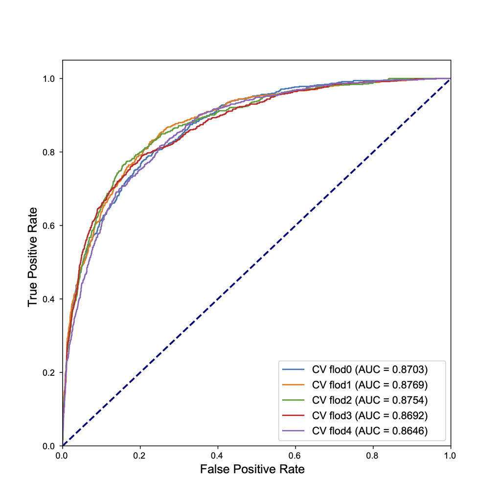

cross ROC

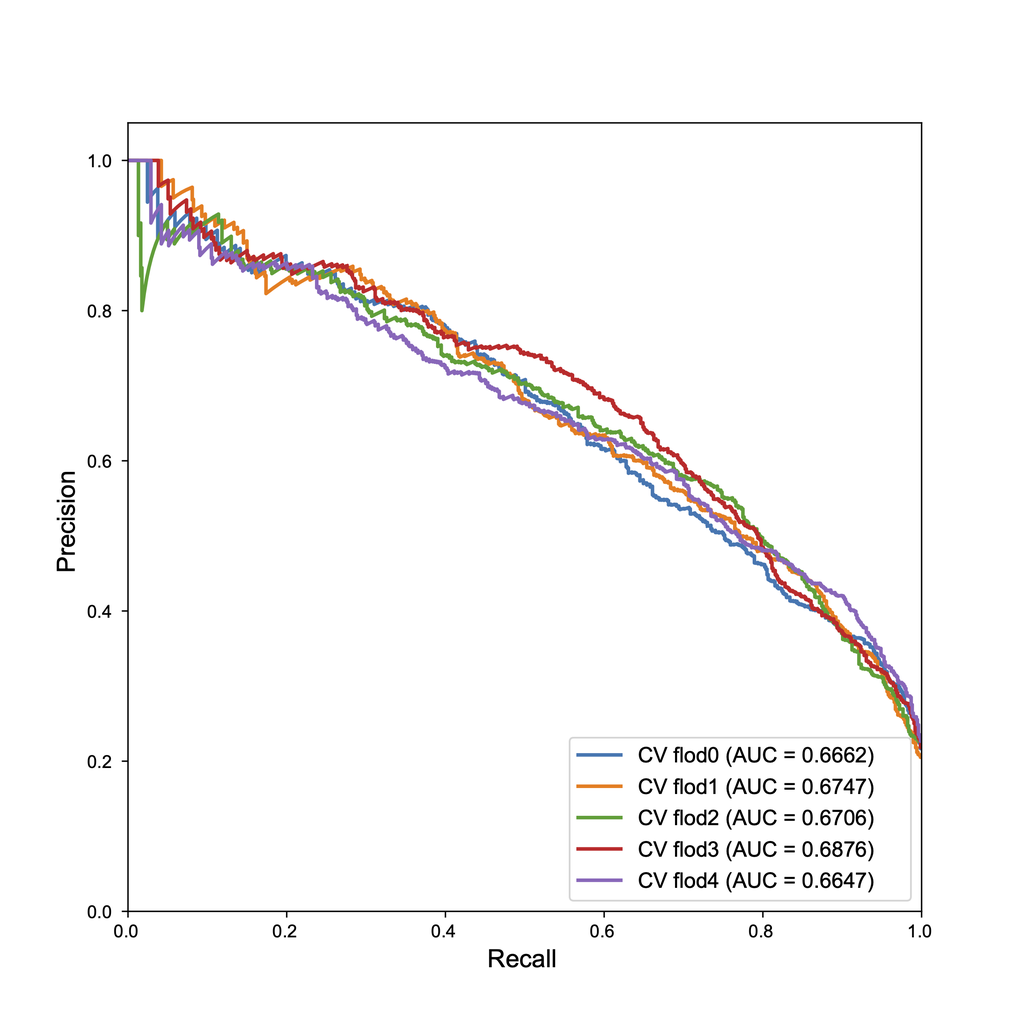

cross PR

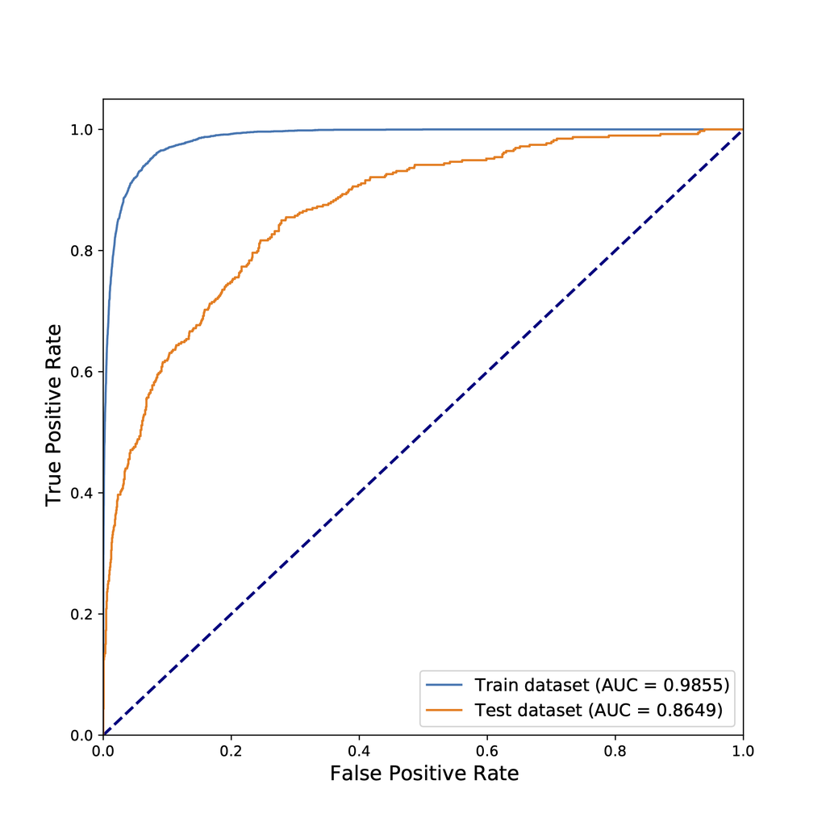

ROC

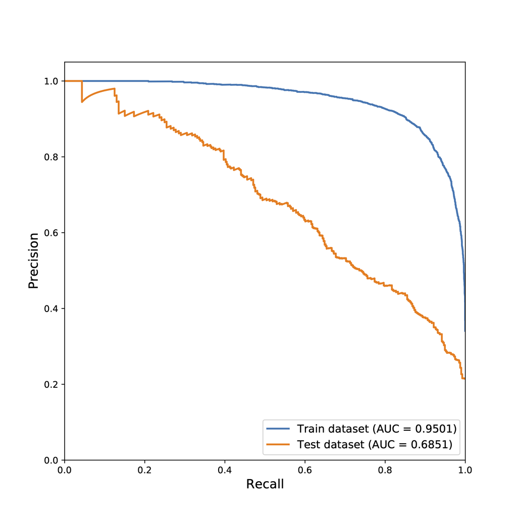

PR

### model test dataset

```python
data = pd.read_csv("../data/model_test.csv")
data["len"] = data["peptide"].map(len)
data2 = data[data["len"] >= 15]
data2["peptide"].to_csv("../data/model_test_pep.csv",index = None,header = None)
oridata = pd.read_csv("../data/IEDB_MHCII_immuno.csv")
data1 = pd.merge(data,oridata[["Allele Name","Allele Name1"]],left_on = "MHC",right_on = "Allele Name1").drop_duplicates()
data1.to_csv("../data/model_test_netMHCIIpan.csv",index = None)
```

```python
#pbs
#python
import pandas as pd
import os
import tensorflow as tf
from tensorflow import keras
from tensorflow.keras import layers
from tensorflow.keras.layers import *
from sklearn.model_selection import train_test_split,KFold
import numpy as np
from collections import Counter
os.environ["CUDA_VISIBLE_DEVICES"] = "-1"
from sklearn.metrics import auc,precision_recall_curve,roc_curve,confusion_matrix,average_precision_score
from collections import Counter
import matplotlib.pyplot as plt
import matplotlib as mpl
mpl.rcParams['pdf.fonttype'] = 42
mpl.rcParams['ps.fonttype'] = 42
plt.rcParams.update({'font.family':'Arial'})
import sys
sys.path.append("/public/slst/home/wanggsh/Project/MHCII/utils")
from Blosum62 import blosum62
#Data process
immuno_data = pd.read_csv("/public/slst/home/wanggsh/Data/MHCII_immuno/IMM_data_random2.csv")

immuno_data["pep_blosum"] = immuno_data["Description"].apply(blosum62,args=(21,))
immuno_data["MHC_blosum"] = immuno_data["sequence"].apply(blosum62,args=(34,))
peptide = np.empty((len(immuno_data),21,21))
for i in range(len(immuno_data)):
    peptide[i] = immuno_data["pep_blosum"][i].reshape((21,21))
#mhc
MHC = np.empty((len(immuno_data),34,21))
for i in range(len(immuno_data)):
    MHC[i] = immuno_data["MHC_blosum"][i].reshape((34,21))


labels = immuno_data["label"].values

BAmodel = tf.keras.models.load_model("/public/slst/home/wanggsh/Project/Saved_model/new_BA_model/model1")
BAmodel = tf.keras.models.Model(inputs = BAmodel.input,outputs = BAmodel.layers[-2].output)
BA = BAmodel.predict([peptide,MHC])

#class weight
neg, pos = np.bincount(immuno_data["label"])
total = neg + pos
print('Examples:\n    Total: {}\n    Positive: {} ({:.2f}% of total)\n'.format(
    total, pos, 100 * pos / total))

weight_for_0 = (1 / neg) * (total / 2.0)
weight_for_1 = (1 / pos) * (total / 2.0)

class_weight = {0: weight_for_0, 1: weight_for_1}

print('Weight for class 0: {:.2f}'.format(weight_for_0))
print('Weight for class 1: {:.2f}'.format(weight_for_1))


pep_Train,pep_Test,MHC_Train,MHC_Test,label_Train,label_Test,BA_Train,BA_Test = train_test_split(peptide,MHC,labels,BA,test_size=0.1,random_state=202205,stratify=labels)
print(Counter(label_Train))
print(Counter(label_Test))
print("Data progress finish!!")




# Cross validation
print("Cross Validation")



model = tf.keras.models.load_model("/public/slst/home/wanggsh/Project/Saved_model/MHCII_immuno/model")


prediction = model.predict([pep_Test,MHC_Test,BA_Test])
Train_pre = model.predict([pep_Train,MHC_Train,BA_Train])
fpr,tpr,thresholds = roc_curve(label_Test,prediction,pos_label=1)
train_fpr,train_tpr,_ = roc_curve(label_Train,Train_pre,pos_label=1)
area_mine = auc(fpr,tpr)
area_mine_train = auc(train_fpr,train_tpr)
print(area_mine)
print(area_mine_train)

precision,recall,thresholds = precision_recall_curve(label_Test,prediction,pos_label=1)
precision_train,recall_train,_ = precision_recall_curve(label_Train,Train_pre,pos_label=1)
area_PR = auc(recall,precision)
area_PR_train = auc(recall_train,precision_train)


fig,ax = plt.subplots(figsize = (8,8))
lw = 2
ax.plot([0, 1], [0, 1], color='navy', lw=lw, linestyle='--')
ax.plot(train_fpr,train_tpr,label='Train dataset (AUC = {0:.4f})'.format(area_mine_train))
ax.plot(fpr,tpr,label='Test dataset (AUC = {0:.4f})'.format(area_mine))
plt.xlim([0.0, 1.0])
plt.ylim([0.0, 1.05])
plt.xlabel("False Positive Rate",fontsize = 14)
plt.ylabel("True Positive Rate",fontsize = 14)
plt.title("")
plt.legend(loc="lower right",fontsize = 12)
plt.savefig("/public/slst/home/wanggsh/Project/Saved_model/Model_fig/Immuno_model/ROC_1121.pdf",dpi = 300,transparent=True)

fig,ax = plt.subplots(figsize = (8,8))
lw = 2
ax.plot(recall_train,precision_train,lw=lw, label = 'Train dataset (AUC = {0:.4f})'.format(area_PR_train))
ax.plot(recall,precision,lw=lw, label = 'Test dataset (AUC = {0:.4f})'.format(area_PR))
plt.xlim([0.0, 1.0])
plt.ylim([0.0, 1.05])
plt.xlabel('Recall',fontsize = 14)
plt.ylabel('Precision',fontsize = 14)
plt.title("")
plt.legend(loc="lower right",fontsize = 12)
plt.savefig("/public/slst/home/wanggsh/Project/Saved_model/Model_fig/Immuno_model/PR_1121.pdf",dpi = 300,transparent=True)

def auc_pr(data,true_label,prediction,rank = False):
    if rank:
        fpr,tpr,_ = roc_curve(data[true_label],1-data[prediction])
        precision,recall,_ = precision_recall_curve(data[true_label],1-data[prediction])
    else:
        fpr,tpr,_ = roc_curve(data[true_label],data[prediction])
        precision,recall,_ = precision_recall_curve(data[true_label],data[prediction])

    AUC = auc(fpr,tpr)
    PR = auc(recall,precision)

    return fpr,tpr,recall,precision,AUC,PR

data = pd.read_csv("/public/slst/home/wanggsh/Data/new/model_test.csv")
test_iedb = pd.read_csv("/public/slst/home/wanggsh/Data/new/model_test_iedb.csv")
test_iedb = pd.merge(data,test_iedb,left_on = "peptide",right_on = "Peptide")
test_iedb_result = auc_pr(test_iedb,"Label","Immunogenicity Score",rank = True)
test_repitope = pd.read_csv("/public/slst/home/wanggsh/Data/new/model_test_repitope.csv")
test_repitope = pd.merge(data,test_repitope,left_on = "peptide",right_on = "Peptide")
test_repitope_result = auc_pr(test_repitope,"Label","ImmunogenicityScore")
test_net_ba = pd.read_csv("/public/slst/home/wanggsh/Data/new/model_test_ba.csv")
test_net_ba = pd.merge(data,test_net_ba,left_on = "peptide",right_on = "peptide")
test_net_ba_result = auc_pr(test_net_ba,"Label","percentile_rank",rank = True)
test_net_el = pd.read_csv("/public/slst/home/wanggsh/Data/new/model_test_el.csv")
test_net_el = pd.merge(data,test_net_el,left_on = "peptide",right_on = "peptide")
test_net_el_result = auc_pr(test_net_el,"Label","percentile_rank",rank = True)

fig,ax = plt.subplots(figsize = (8,8))
lw = 2
ax.plot([0, 1], [0, 1], color='navy', lw=lw, linestyle='--')
ax.plot(fpr,tpr,label='TLimmuno2 : (AUC = {0:.4f})'.format(area_mine))
ax.plot(test_iedb_result[0],test_iedb_result[1],label='IEDB : (AUC={0:.4f})'.format(test_iedb_result[4]),linewidth = 2)
ax.plot(test_repitope_result[0],test_repitope_result[1],label='Repitope : (AUC={0:.4f})'.format(test_repitope_result[4]),linewidth = 2)
ax.plot(test_net_ba_result[0],test_net_ba_result[1],label='NetMHCIIpan_ba : (AUC={0:.4f})'.format(test_net_ba_result[4]),linewidth = 2)
ax.plot(test_net_el_result[0],test_net_el_result[1],label='NetMHCIIpan_el : (AUC={0:.4f})'.format(test_net_el_result[4]),linewidth = 2)
plt.xlim([0.0, 1.0])
plt.ylim([0.0, 1.05])
plt.xlabel("False Positive Rate",fontsize = 14)
plt.ylabel("True Positive Rate",fontsize = 14)
plt.title("")
plt.legend(loc="lower right",fontsize = 12)
plt.savefig("/public/slst/home/wanggsh/Data/new/test_com_ROC_1121.pdf",dpi = 300,transparent=True)

fig,ax = plt.subplots(figsize = (8,8))
lw = 2
ax.plot(recall,precision,lw=lw, label = 'Test dataset (AUC = {0:.4f})'.format(area_PR))
ax.plot(test_iedb_result[2],test_iedb_result[3],label='IEDB : (AUC={0:.4f})'.format(test_iedb_result[5]),linewidth = 2)
ax.plot(test_repitope_result[2],test_repitope_result[3],label='Repitope : (AUC={0:.4f})'.format(test_repitope_result[5]),linewidth = 2)
ax.plot(test_net_ba_result[2],test_net_ba_result[3],label='NetMHCIIpan_ba : (AUC={0:.4f})'.format(test_net_ba_result[5]),linewidth = 2)
ax.plot(test_net_el_result[2],test_net_el_result[3],label='NetMHCIIpan_el : (AUC={0:.4f})'.format(test_net_el_result[5]),linewidth = 2)
plt.xlim([0.0, 1.0])
plt.ylim([0.0, 1.05])
plt.xlabel('Recall',fontsize = 14)
plt.ylabel('Precision',fontsize = 14)
plt.title("")
plt.legend(loc="lower right",fontsize = 12)
plt.savefig("/public/slst/home/wanggsh/Data/new/test_com_PR_1121.pdf",dpi = 300,transparent=True)
print("Finish")
```